# GRAM Simulation

Calibration and Benchmarking

Sigal Maya

Updated 03/10/2025

#### **sim1: Initial model**

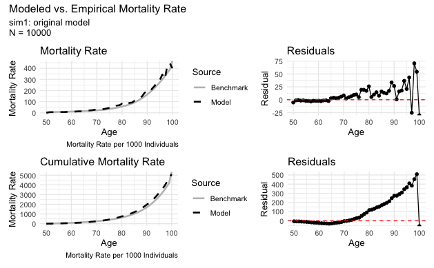

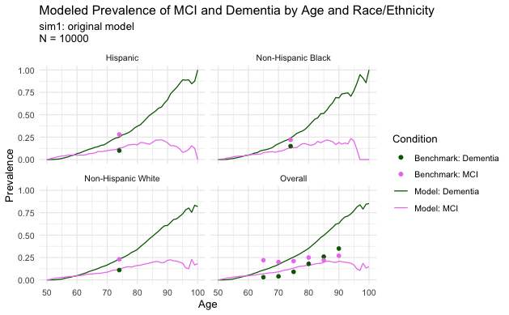

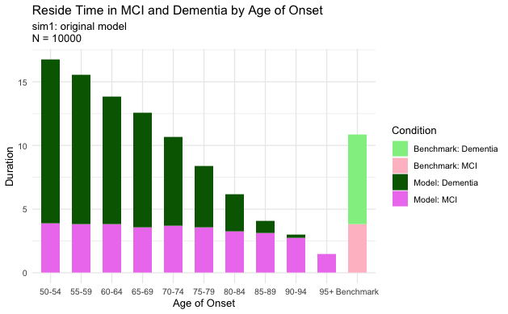

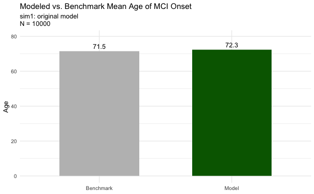

Observations: 1. Modeled mortality is higher than benchmark, with increasing error with age. 2. MCI prevalence is too low, dementia prevalence is too high. 3. Reside times in both MCI and dementia seem to be spot on. 4. Modeled mean age of onset is slightly older than benchmark (71.5 vs 72.3, which is about 1%).

Dementia prevalence is too high, which is likely causing the high mortality in older ages. The only way to get dementia in the model is to (a) get MCI, then (b) progression in CDR score. Increasing MCI incidence will push up dementia prevalence, reducing it will further reduce MCI prevalence (which is already lower than we want it to be). So I will first try to reduce CDR progression rate.

#### **sim2: Reduced CDR progression rate by 50% while in MCI**

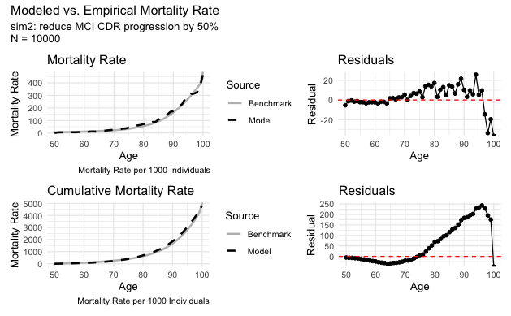

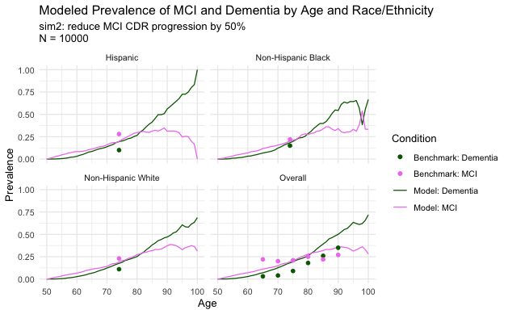

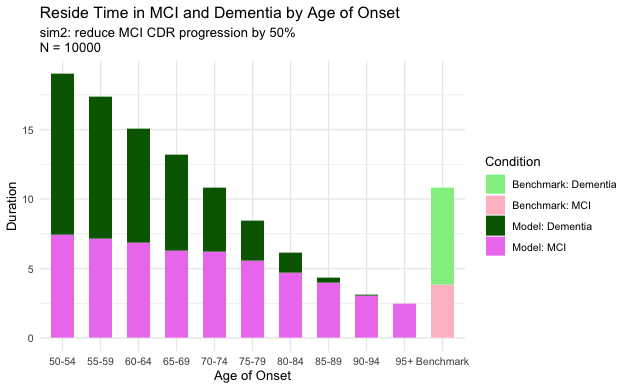

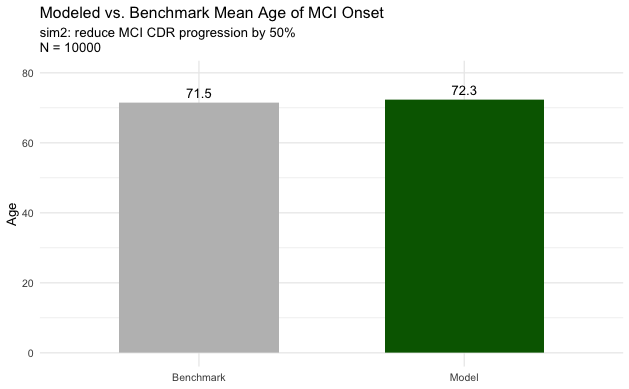

As expected, that did help lower mortality, increase MCI prevalence closer to benchmark, and decrease dementia prevalence closer to benchmark (though still a bit higher). But it also increased reside time. I need to lower mortality a little more, and also lower dementia prevalence. Try lowering MCI incidence (baseline / no risk factor) instead.

#### **sim3: Reduce baseline (reference) MCI hazard rate**

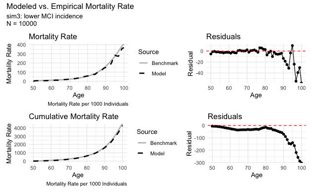

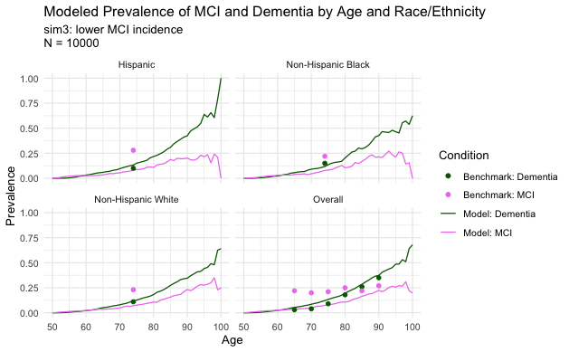

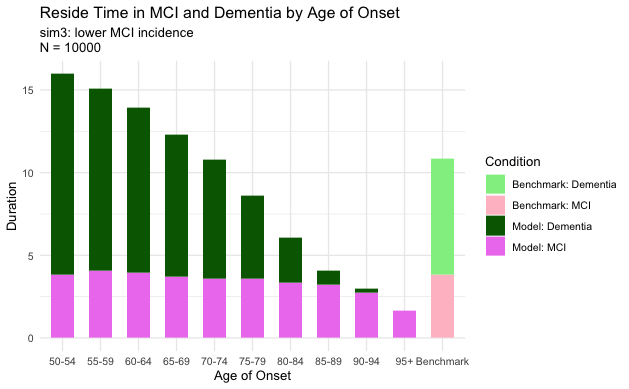

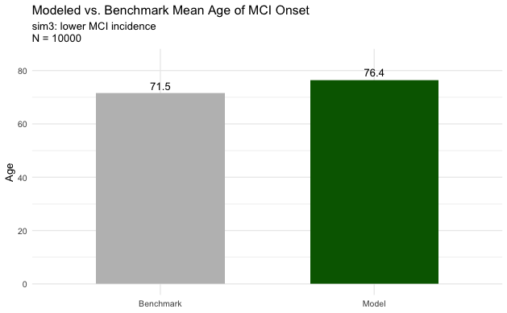

Dementia prevalence seems acceptable but mortality at older ages is too low. Reduce dementia mortality adjustment for age - maybe we are already account for most of that in our estimation of non-dementia mortality.

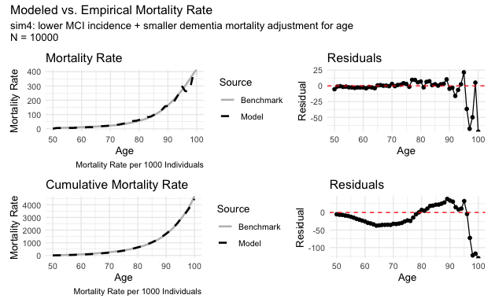

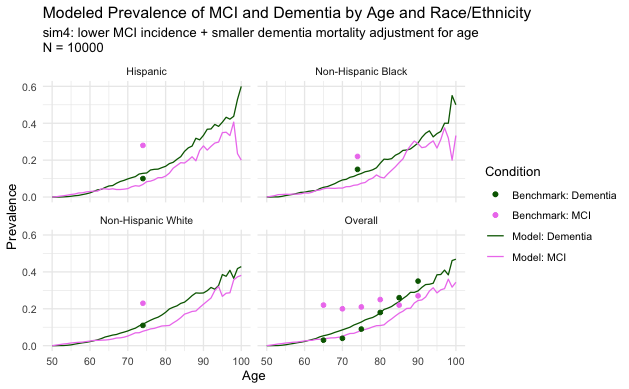

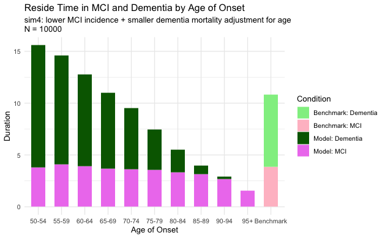

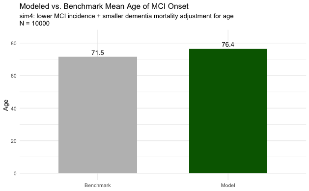

#### **sim5: Introduce MCI hazard function coefficients for Black and Hispanic.**

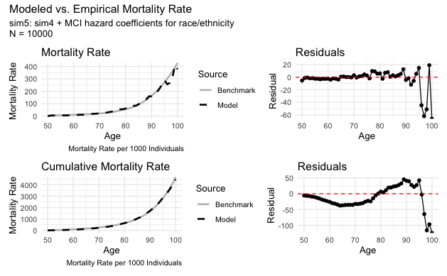

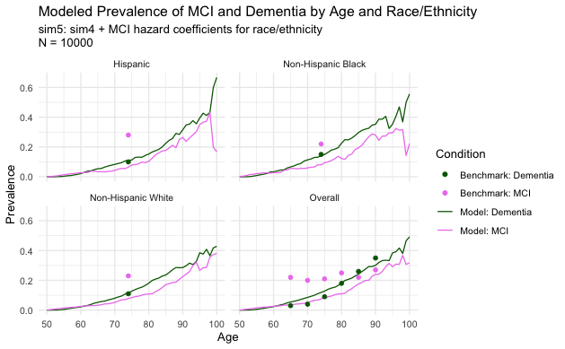

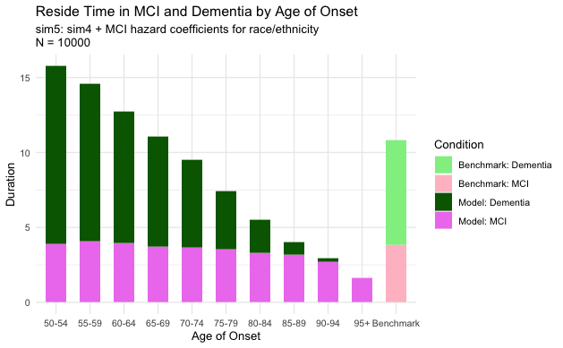

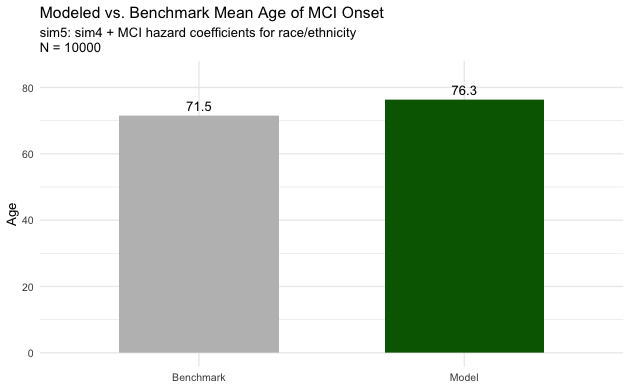

#### **sim6: sim5 + prevalent starting cohort**

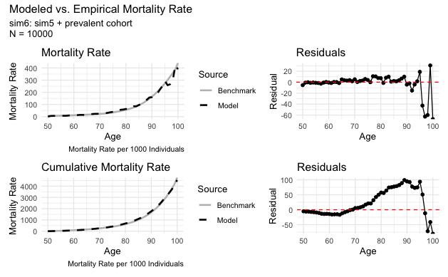

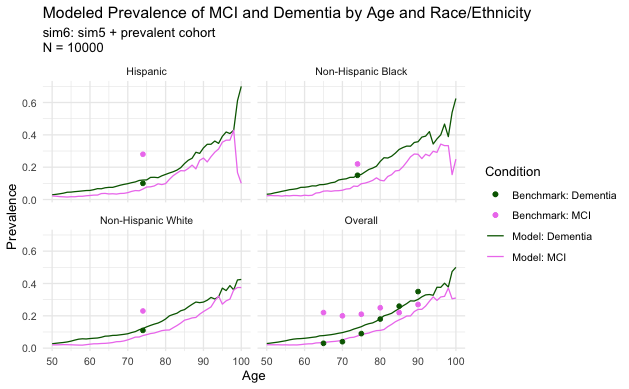

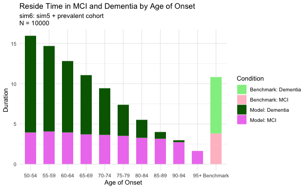

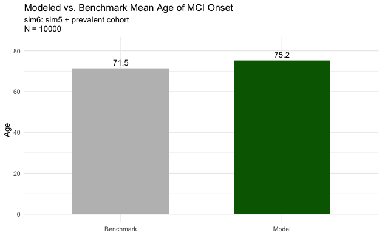

Not much changed, but it did bring down the average age of onset. It seems that the only way to have more MCI than dementia is to have people stay in MCI for longer. But, that means the model has longer reside times than benchmark.

#### **sim7**

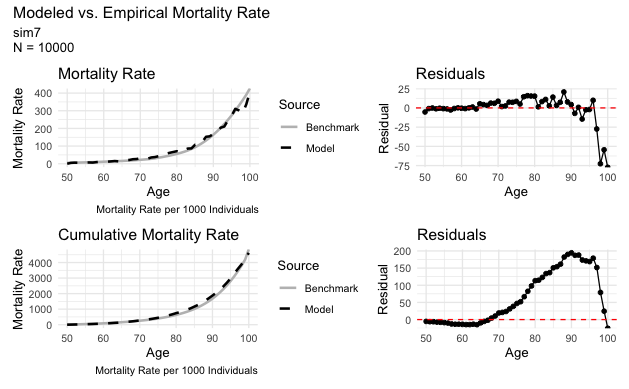

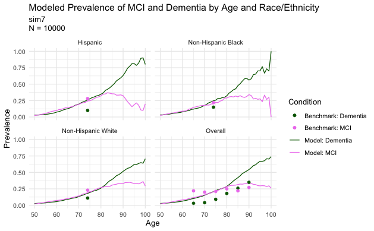

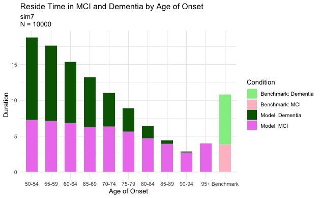

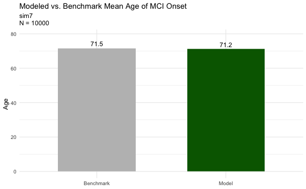

It’s really hard to de-couple dementia prevalence from MCI prevalence. Wondering if a uniform random increase in CDR-SB is not a good strategy. For example, APOE4 carriers more likely to progress. I think that’s why it’s not possible to get both MCI/dementia prevalence and reside times right. Once you get into MCI, you’re in a set trajectory that doesn’t allow for much variation (there is a standard deviation from the mean but that’s fixed per individual and it’s quite small). If we can have more granularity on the rate of progression to dementia (which will not be a random factor – this is dependent on many things), I think we will be able to get closer to benchmarks on both areas.